# TFN Modeling and Time Sereis Forecasting Examples

JENWEN LIN

March 7, 2020

# 1 `R` libraries and Data

```r
library(knitr)
library(readxl)
library(MASS)
library(forecast)
library(timeSeries)
library(timeDate)
library(sarima)
```

- Three **R** functions, `PreWhiten.ar`, `PreWhiten.arma` and `LBTest`, will be posted on Quercus.

## 1.1 Import data and processing

Import Google Flu Trends (GFT) and numbers of flu tests (fluTest) and split the dataset into two samples

- Training sampel: start = “2003-09-28”, end = “2014-08-10”
- Test sample: start = “2014-08-17”, end = “2015-08-09”

### 1.1.1 Training sample

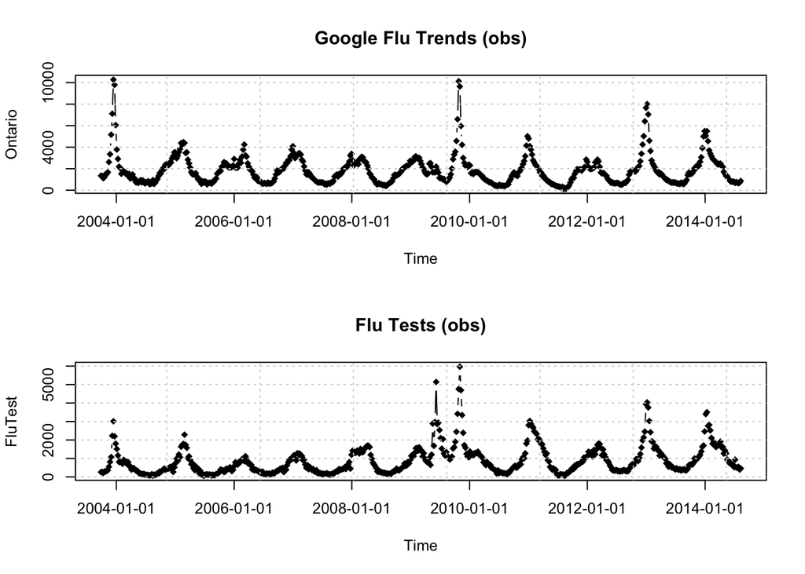

### 1.1.2 Test sample

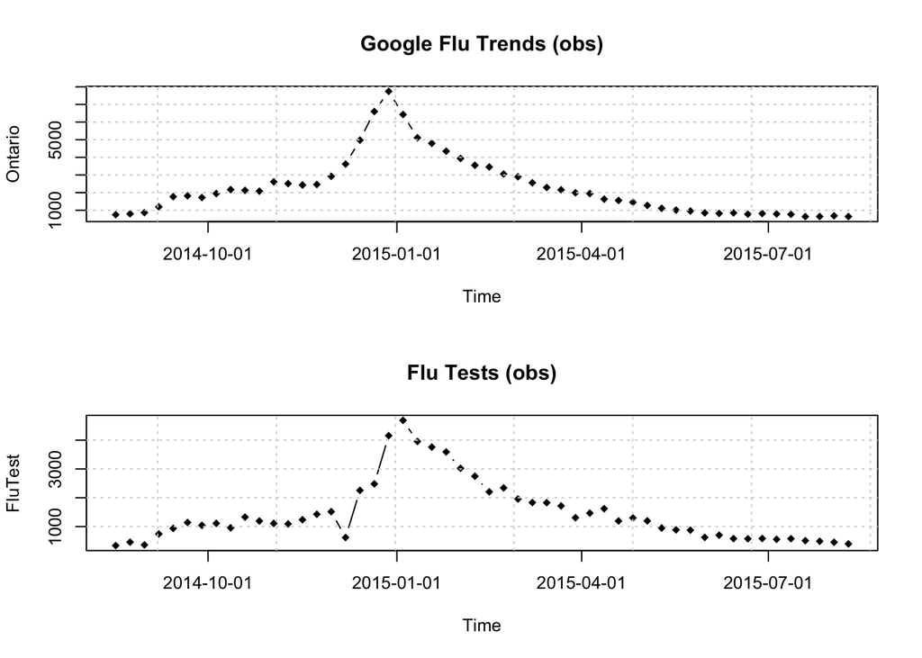

## 1.2 Testing `PreWhiten.xx` functions

- Two reverse filters are provided: `PreWhiten.ar` & `PreWhiten.arma`

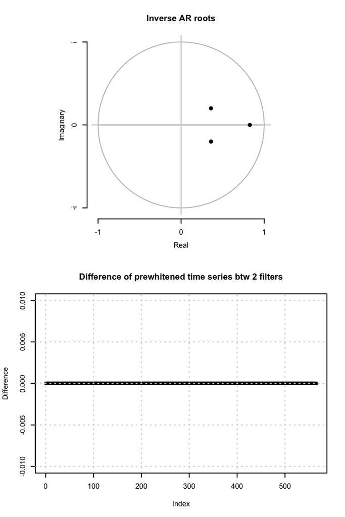

```r
mod.ar <- auto.arima(GFT.obs, max.p = 52, max.q = 0, stationary = TRUE) #, allowmean = FALSE)
temp = PreWhiten.arma(GFT.obs, ar = mod.ar$coef[1:3], ma = 0)
temp1 = PreWhiten.ar(GFT.obs, ar = mod.ar$coef[1:3])
par(mfrow = c(2,1), cex =0.5)
plot(mod.ar)
plot(c(temp1)-temp[-(1:3)], col = 1,
     ylab = "Difference", ylim = c(-0.01,0.01), pch = 15,
     main = "Difference of prewhitened time series btw 2 filters")
grid()
```

- **Remark:** We may prewhiten the data and build the transfer function using the transformed time series.

```r
# Box-Cox transformation
c(BoxCox.lambda(GFT), BoxCox.lambda(fluTest))
```

```
## [1] 0.04139756 0.14534454
```

# 2 Modeling `Google Flu Trends`

## 2.1 Model selection and estimation

We use the `auto.arima` function in `forecast` package to fit `GFT`, and as shown below.

```r
mod.arma<-auto.arima(GFT.obs, max.p = 52, max.q = 52, stationary = TRUE)
p = mod.arma$arma[1]; q = mod.arma$arma[2]
coef(mod.arma)
```

```
##          ar1          ar2          ar3          ma1          ma2    intercept
##    0.3881350    0.8215992   -0.4010571    1.1508921    0.1957950 1837.5068498
```

An ARMA(3, 2) model is selected based on AIC.

Copyright (c) 2020 JEN-WEN LIN

## 2.2 Stablility of the fitted ARMA model

The **inverse** AR and MA roots are all inside the unit circle so the fitted ARMA model is *causal* and *invertible*.

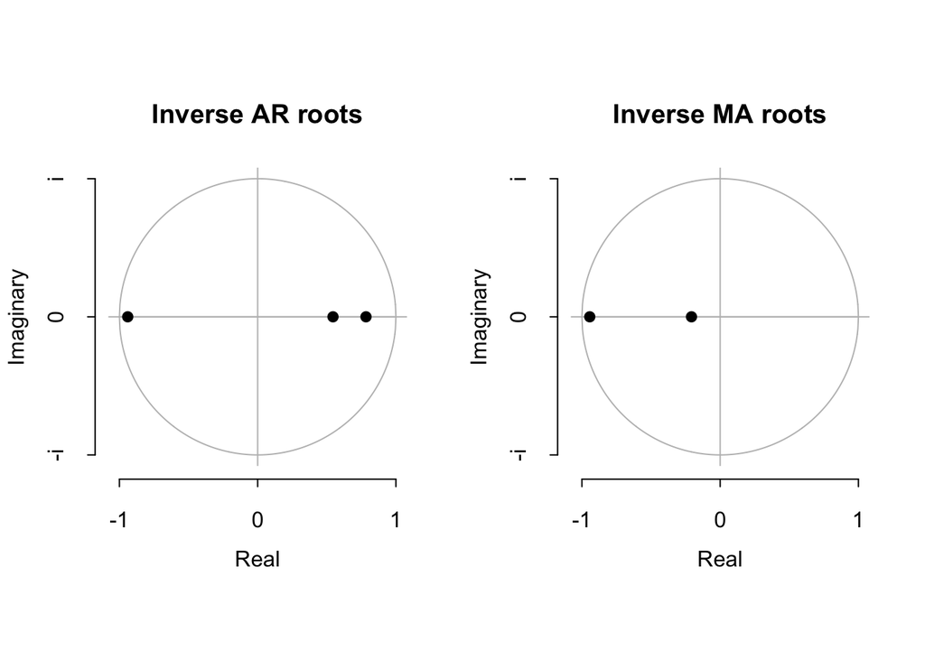

Copyright (c) 2020 JEN-WEN LIN

## 2.3 Model adequacy

As mentioned in the class last week, the `checkresiduals` function is not recommened. Use the provided `LBTest` function to test the model adequacy instead. As shown below, the p-values of the test statistics are well above the 5% significance level so the fitted model is adequacy.

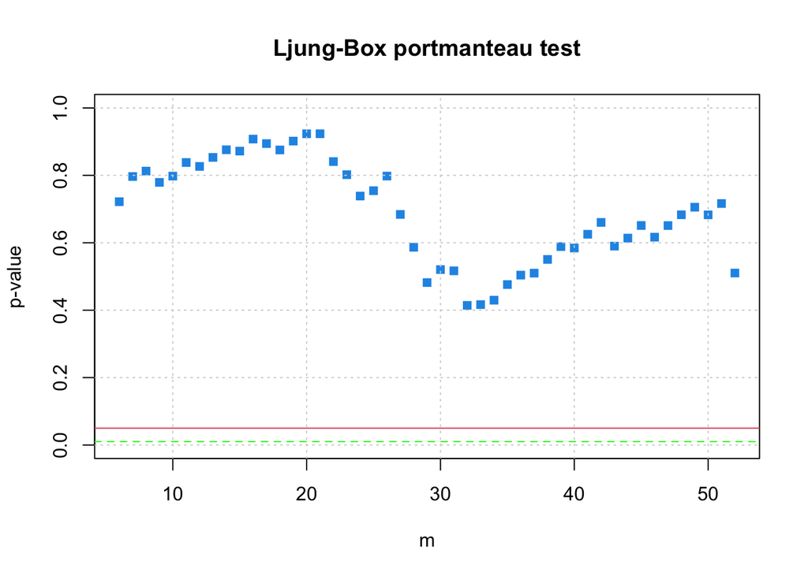

```r
npq = sum(mod.arma$arma[c(1,2)])
LBTest(mod.arma$residuals, nPQ = npq, m = 52, ifPlot = TRUE)
```

Copyright (c) 2020 JEN-WEN LIN

# 3 Modeling Flu Tests using `Google Flue Trends`

## 3.1 `Google Flue Trends` lag selection

Select `Google Flue Trends` lags using prewhitening and the provided `PreWhiten.arma` function.

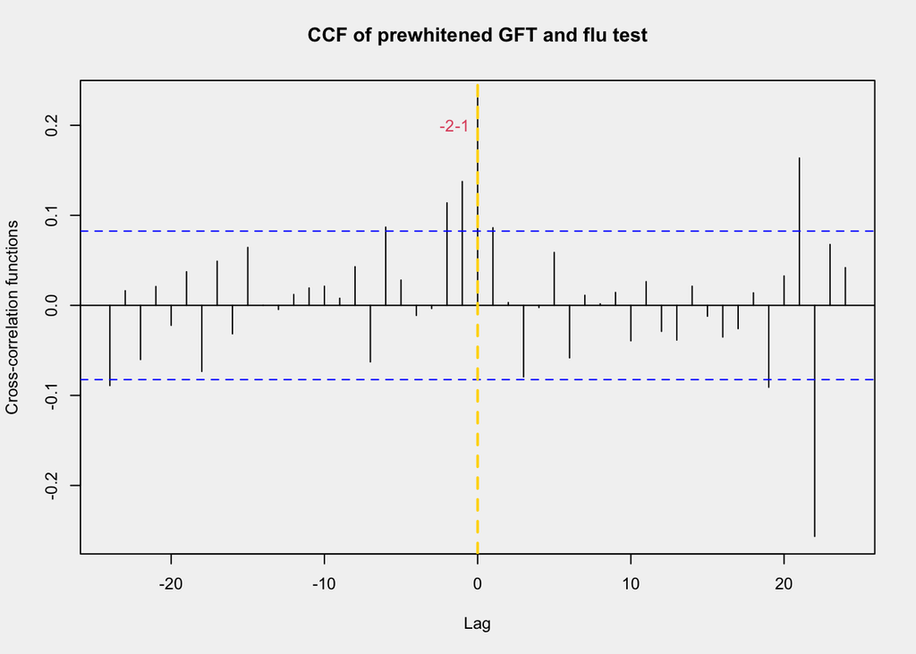

```r
mod = mod.arma;nAR = mod$arma[1]; nMA = mod$arma[2]

if(nMA!=0){
  xf = PreWhiten.arma(GFT.obs, ar = mod$coef[1:nAR],
                      ma = mod$coef[(1:nMA)+nAR])[-(1:nAR)]
  yf = PreWhiten.arma(fluTest.obs, ar = mod$coef[1:nAR],
                      ma=mod$coef[(1:nMA)+nAR])[-(1:nAR)]
}else{
  xf = PreWhiten.arma(GFT.obs, ar = mod$coef[1:nAR],
                      ma = 0)[-(1:nAR)]
  yf = PreWhiten.arma(fluTest.obs, ar = mod$coef[1:nAR],
                      ma=0)[-(1:nAR)]
}

par(cex=0.75,bg="gray95")
ccf(c(xf), c(yf), lwd=1, ylab="Cross-correlation functions",
    main="CCF of prewhitened GFT and flu test")
abline(v=0, col="gold", lwd=2, lty="dashed")
text(-1, 0.2, "-1", col=2)
text(-2, 0.2, "-2", col=2)
```

As shown above, we will include $GFT_t, GFT_{t-1}, GFT_{t-2}$ in our transfer function noise model.

Copyright (c) 2020 JEN-WEN LIN

## 3.2 TFN estimation

For simplicity, we use `auto.arima` function to complete the selection and estimation of the transfer fuction noise model.

```r
y<-fluTest
x<-GFT
dat<- cbind(y,x, lag(x), lag(x,2))[-c(1:5),]
colnames(dat)<-c("fluTest", "GFT", "GFT1", "GFT2")
data<- timeSeries(dat, charvec = tim)

data.obs = window(data, start = "2003-10-12", end = "2014-08-10")
data.test = window(data, start = "2014-08-17", end = "2015-07-26")

mod.tfn = auto.arima(data.obs[,1], xreg = data.obs[,-1], stationary = TRUE)
coef(mod.tfn)
```

```
##         ar1         ar2         ar3         ma1         ma2         GFT
##  0.25908547 -0.07559495  0.64749351  0.44995972  0.48313420  0.25702614
##        GFT1        GFT2
##  0.09441564  0.09191088
```

- **Question**: What is the fitted TFN model?
- **Question**: What does it mean to include autoregressive terms of `fluTest` in the model?

Copyright (c) 2020 JEN-WEN LIN

## 3.3 Model adequacy

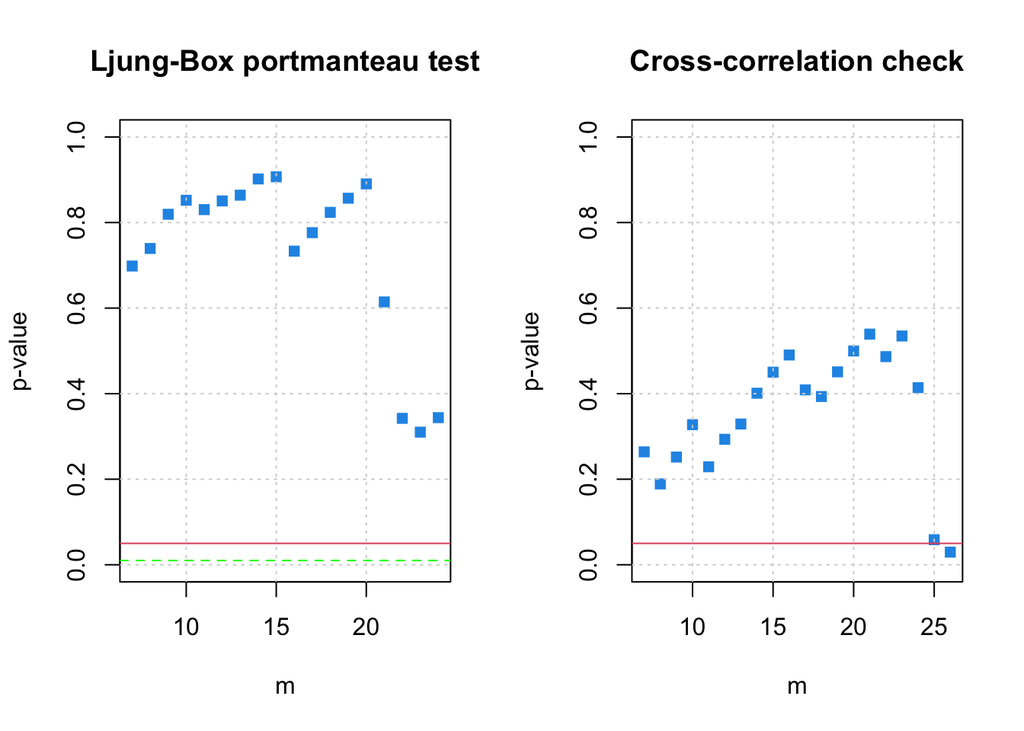

```r
m = 26
lags = 1:m
df <- (3+3+1):m
n = length(mod.tfn$res)
rccf = ccf(mod$residuals,mod.tfn$residuals, plot = FALSE, lag.max = m)$acf[-(1:m)]
Qm = n* (n + 2) * cumsum((rccf^2)/(n - (0:m)))[df]
pv <- 1 - pchisq(Qm, df)
a = cbind(df, Qm,pv)

par(mfrow = c(1,2))
LBTest(mod.tfn$res, nPQ = 6, ifPlot = TRUE)
plot(x = a[,1],y = a[,3],
     ylim = c(0,1), pch = 15, col =4,
     ylab = "p-value", xlab = "m",
     main = "Cross-correlation check")
abline(h =0.05, col =2)
grid()
```

- **Question**: Is the fitted TFN model adequate?

Copyright (c) 2020 JEN-WEN LIN

## 3.4 `fluTest` and the fitted TFN model

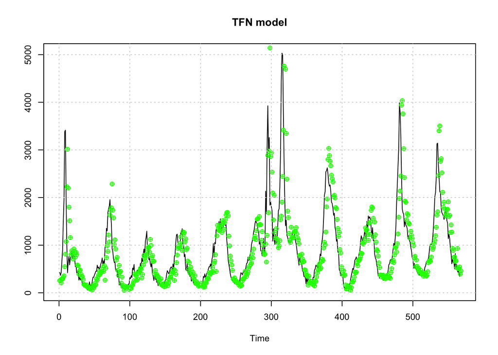

```r
par(mfrow = c(1,1), cex = 0.75)
ts.plot(mod.tfn$fitted, ylab = "", main ="TFN model")
lines(c(fluTest.obs), pch = 10, col = "green", type ="p")
grid()
```

Copyright (c) 2020 JEN-WEN LIN

# 4 Forecasting

In this section, we fit and compare the forecasting performance of several time series models for predicting `fluTest` time series. Specifically, we also consider *TFN*, *ARIMA*, and neural network.

## 4.1 ARIMA model

The `auto.arima` function is used again to select ARIMA model (based on AIC). The model parameters and relevant tests results are shown below.

```
##        ar1        ar2        ma1        ma2        ma3
## -0.3860444 -0.6072500  0.4750888  0.6861499  0.2501865
```

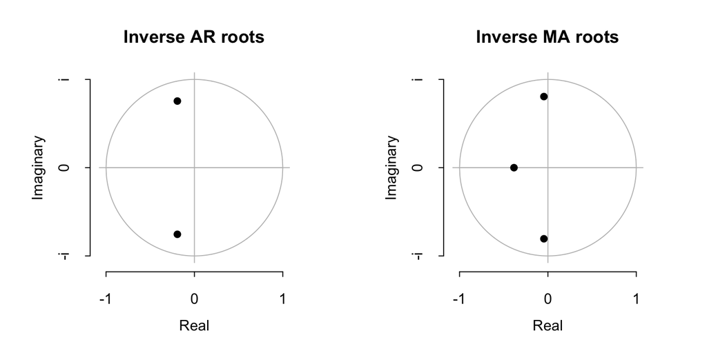

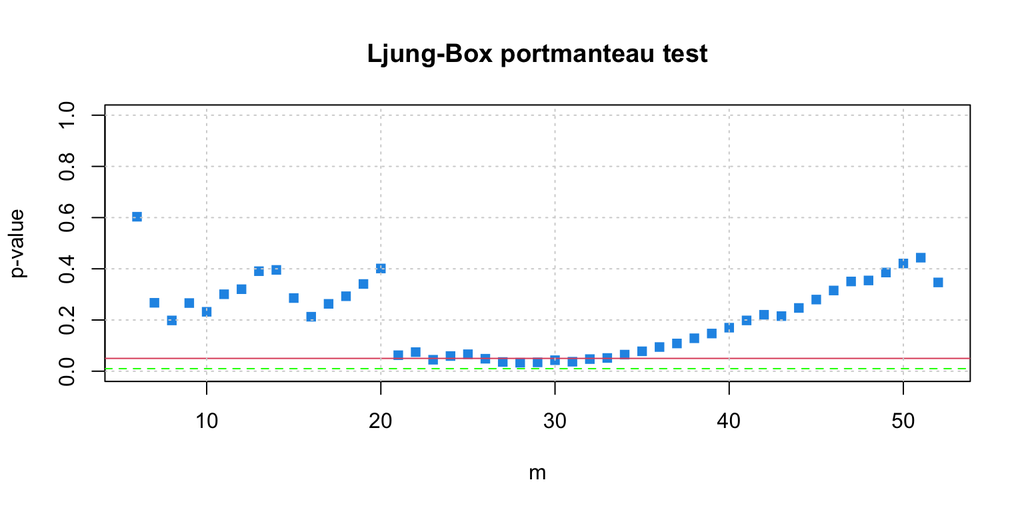

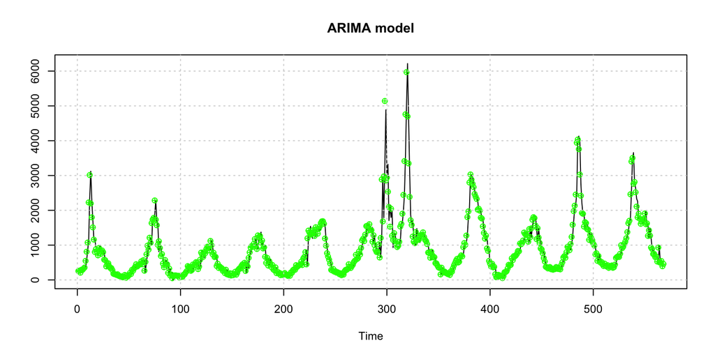

- **Exercise:** Is the fitted ARIMA model adequate?

Copyright (c) 2020 JEN-WEN LIN

## 4.2 Neural networks

We use the `nnetar` function to fit neural network to `fluTest` this section and the fitted model is shown below, where the `mod.nnx` model includes the three `Google Flu Trends` variables.

```r
mod.nn = forecast::nnetar(fluTest.obs);mod.nn
```

```
## Series: fluTest.obs
## Model:  NNAR(7,4)
## Call:   forecast::nnetar(y = fluTest.obs)
##
## Average of 20 networks, each of which is
## a 7-4-1 network with 37 weights
## options were - linear output units
##
## sigma^2 estimated as 32860
```

```r
mod.nnx = forecast::nnetar(data.obs[,1], xreg = data.obs[,-1]);mod.nnx
```

```
## Series: data.obs[, 1]
## Model:  NNAR(6,5)
## Call:   forecast::nnetar(y = data.obs[, 1], xreg = data.obs[, -1])
##
## Average of 20 networks, each of which is
## a 9-5-1 network with 56 weights
## options were - linear output units
##
## sigma^2 estimated as 17387
```

```r
mod.nns = forecast::nnetar(fluTest.obs, P=52);mod.nns
```

```
## Series: fluTest.obs
## Model:  NNAR(7,4)
## Call:   forecast::nnetar(y = fluTest.obs, P = 52)
##
## Average of 20 networks, each of which is
## a 7-4-1 network with 37 weights
## options were - linear output units
##
## sigma^2 estimated as 34181
```

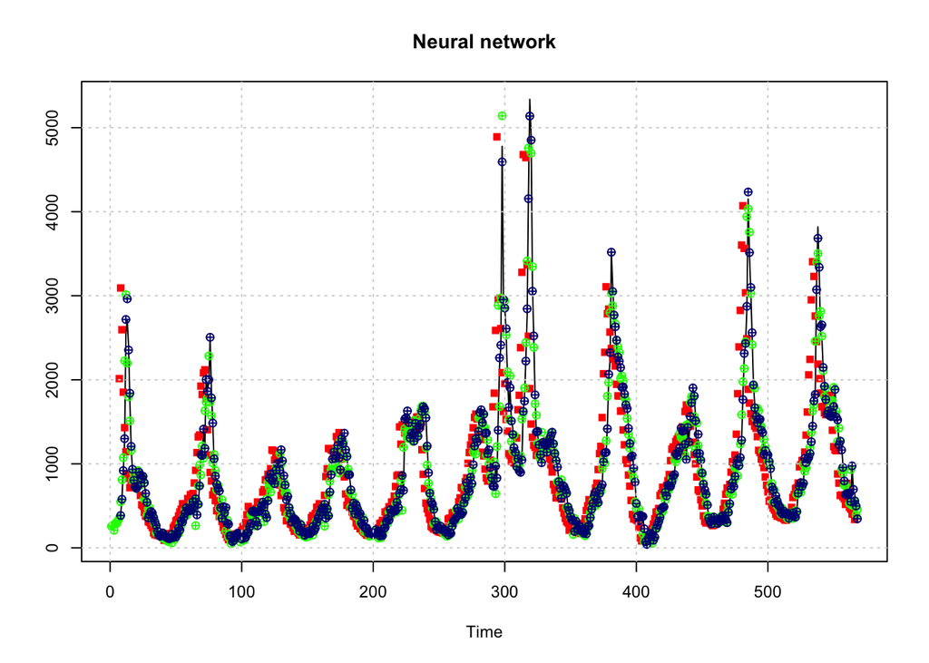

```r
par(mfrow = c(1,1), cex = 0.75)
ts.plot(mod.nn$fitted, ylab = "", main ="Neural network")
lines(c(mod.nnx$fitted), col = "red", lwd = 2, type ="p", pch = 15)
lines(c(fluTest.obs), pch = 10, col = "green", type ="p")
lines(c(mod.nns$fitted), pch = 10, col = "navy", type ="p")

grid()
```

Copyright (c) 2020 JEN-WEN LIN

## 4.3 The 50 step-ahead forecasts

`fulTest` time series and forecasts from four models are plotted below.

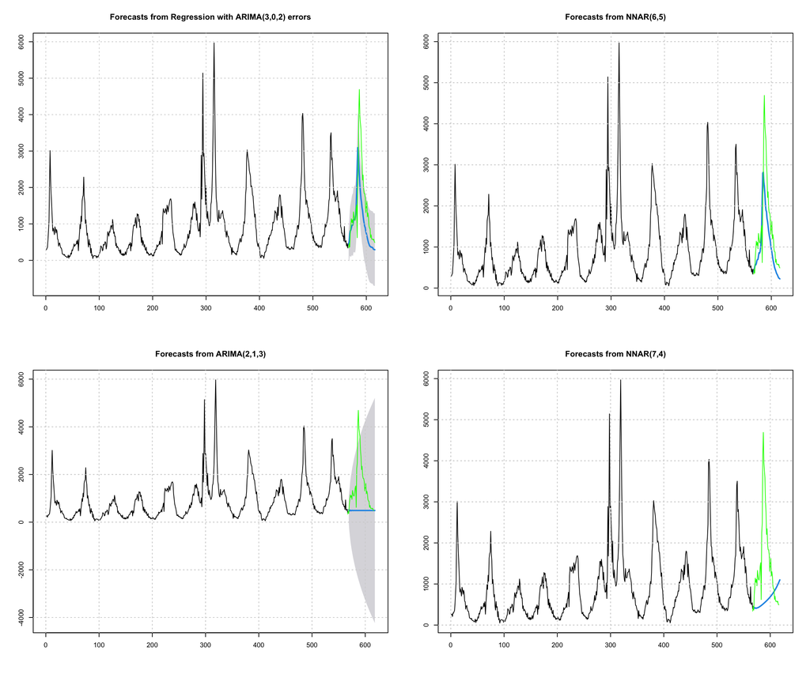

- **Question:** Can you find any pattern from the above plot?

Copyright (c) 2020 JEN-WEN LIN

# 5 Forecast Evaluation

In this section, we use forecast statistics to evaluate the forecast performance of for univariate time series models–`arima`, `tfn`, `nn`, and `nnx`.

## 5.1 Training-sample performance

Training-sample forecast accuracy

|  | ME | RMSE | MAE | MPE | MAPE | MASE | ACF1 |
| --- | --- | --- | --- | --- | --- | --- | --- |
| arima | 0.34 | 281.52 | 153.63 | -3.06 | 20.62 | 0.98 | 0.00 |
| tfn | 6.53 | 225.36 | 126.50 | -7.21 | 19.90 | 0.81 | 0.02 |
| nn | -2.01 | 181.27 | 116.63 | -5.99 | 18.29 | 0.75 | -0.02 |
| nnx | -0.08 | 131.86 | 89.50 | -5.12 | 15.44 | 0.57 | -0.05 |

```
##   ME RMSE  MAE  MPE MAPE MASE ACF1
##    4    4    4    1    4    4    1
```

Copyright (c) 2020 JEN-WEN LIN

## 5.2 Test-sample performance

### 5.2.1 Long-run accuracy (h=50)

Test-sample forecast accuracy (50 weeks)

|  | ME | RMSE | MAE | MPE | MAPE | MASE | ACF1 |
| --- | --- | --- | --- | --- | --- | --- | --- |
| arima | 1015.90 | 1463.47 | 1027.07 | 50.76 | 53.67 | 6.58 | NA |
| tfn | 442.36 | 632.29 | 481.60 | 26.57 | 32.96 | 3.07 | NA |
| nn | 688.17 | 1302.32 | 911.01 | 17.14 | 56.30 | 5.84 | NA |
| nnx | 457.99 | 610.61 | 481.04 | 29.74 | 33.57 | 3.07 | NA |

50 weeks

| ME | RMSE | MAE | MPE | MAPE | MASE | ACF1 |
| --- | --- | --- | --- | --- | --- | --- |
| c(tfn = 2) | c(nnx = 4) | c(nnx = 4) | c(nn = 3) | c(tfn = 2) | c(nnx = 4) | integer(0) |

Copyright (c) 2020 JEN-WEN LIN

### 5.2.2 Short-run accuracy (h=1)

Test-sample forecast accuracy (1 week)

|  | ME | RMSE | MAE | MPE | MAPE | MASE | ACF1 |
| --- | --- | --- | --- | --- | --- | --- | --- |
| arima | -156.74 | 156.74 | 156.74 | -43.06 | 43.06 | 1.00 | NA |
| tfn | -75.34 | 75.34 | 75.34 | -20.70 | 20.70 | 0.48 | NA |
| nn | -95.86 | 95.86 | 95.86 | -26.33 | 26.33 | 0.61 | NA |
| nnx | -26.89 | 26.89 | 26.89 | -7.39 | 7.39 | 0.17 | NA |

1 week

| ME | RMSE | MAE | MPE | MAPE | MASE | ACF1 |
| --- | --- | --- | --- | --- | --- | --- |
| c(nnx = 4) | c(nnx = 4) | c(nnx = 4) | c(nnx = 4) | c(nnx = 4) | c(nnx = 4) | integer(0) |

Copyright (c) 2020 JEN-WEN LIN

### 5.2.3 Short-run accuracy (h=4)

Test-sample forecast accuracy (4 weeks)

|  | ME | RMSE | MAE | MPE | MAPE | MASE | ACF1 |
| --- | --- | --- | --- | --- | --- | --- | --- |
| arima | 302.98 | 425.08 | 381.35 | 24.45 | 45.98 | 2.44 | NA |
| tfn | 171.53 | 228.63 | 209.20 | 15.01 | 25.36 | 1.33 | NA |
| nn | 369.49 | 474.85 | 417.42 | 34.37 | 47.54 | 2.67 | NA |
| nnx | 316.90 | 385.08 | 330.35 | 32.09 | 35.78 | 2.11 | NA |

4 weeks

| ME | RMSE | MAE | MPE | MAPE | MASE | ACF1 |
| --- | --- | --- | --- | --- | --- | --- |
| c(tfn = 2) | c(tfn = 2) | c(tfn = 2) | c(tfn = 2) | c(tfn = 2) | c(tfn = 2) | integer(0) |

Copyright (c) 2020 JEN-WEN LIN

### 5.2.4 Short-run accuracy (h=8)

Test-sample forecast accuracy (8 weeks)

|  | ME | RMSE | MAE | MPE | MAPE | MASE | ACF1 |
| --- | --- | --- | --- | --- | --- | --- | --- |
| arima | 461.88 | 540.72 | 501.06 | 39.85 | 50.62 | 3.21 | NA |
| tfn | 185.17 | 231.87 | 204.00 | 15.96 | 21.13 | 1.30 | NA |
| nn | 521.98 | 590.82 | 545.95 | 47.28 | 53.87 | 3.50 | NA |
| nnx | 398.54 | 444.05 | 405.26 | 37.34 | 39.19 | 2.59 | NA |

8 weeks

| ME | RMSE | MAE | MPE | MAPE | MASE | ACF1 |
| --- | --- | --- | --- | --- | --- | --- |
| c(tfn = 2) | c(tfn = 2) | c(tfn = 2) | c(tfn = 2) | c(tfn = 2) | c(tfn = 2) | integer(0) |

**Copyright (c) 2020 JEN-WEN LIN**

# 6 Vector autoregression

## 6.1 Model selection and estimation

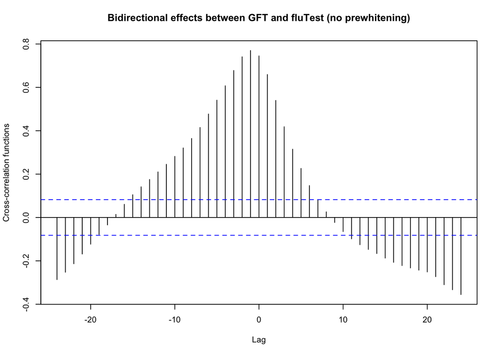

**Copyright (c) 2020 JEN-WEN LIN**

## 6.2 Stability of the fitted VAR model

We construct the companion matrix from the fitted VAR model and use it to evaluate the stability of the model. As shown in the calculation below, all of the eigenvalues lie inside the unit circle so the fitted VAR model is stable.

```r
A = Bcoef(mod.var)[,1:(order*2)]
B = diag(2*(order-1))
C = cbind(rep(0,2*(order-1)),rep(0,2*(order-1)))

M = rbind(A,cbind(B,C))
kable(M, digits = 1, caption = "Companion Matrix")
```

Companion Matrix

|  | Ontario.l1 | FluTest.l1 | Ontario.l2 | FluTest.l2 | Ontario.l3 | FluTest.l3 | Ontario.l4 | FluTest.l4 |
| --- | --- | --- | --- | --- | --- | --- | --- | --- |
| Ontario | 1.5 | 0.2 | -0.7 | -0.2 | 0.1 | -0.1 | 0.0 | 0.0 |
| FluTest | 0.3 | 0.7 | -0.2 | 0.0 | -0.1 | 0.3 | 0.1 | -0.2 |
|  | 1.0 | 0.0 | 0.0 | 0.0 | 0.0 | 0.0 | 0.0 | 0.0 |
|  | 0.0 | 1.0 | 0.0 | 0.0 | 0.0 | 0.0 | 0.0 | 0.0 |
|  | 0.0 | 0.0 | 1.0 | 0.0 | 0.0 | 0.0 | 0.0 | 0.0 |
|  | 0.0 | 0.0 | 0.0 | 1.0 | 0.0 | 0.0 | 0.0 | 0.0 |
|  | 0.0 | 0.0 | 0.0 | 0.0 | 1.0 | 0.0 | 0.0 | 0.0 |
|  | 0.0 | 0.0 | 0.0 | 0.0 | 0.0 | 1.0 | 0.0 | 0.0 |

```r
ev<-eigen(M, only.values = TRUE)$values
all(sqrt(Re(ev)^2+Im(ev)^2)<1)
```

```
## [1] TRUE
```

```r
portes::Hosking(mod.var, order = 3)
```

[output not shown]

- **Question:** Is the fitted VAR(4) moel adequate?

**Copyright (c) 2020 JEN-WEN LIN**

## 6.3 VAR forecasting

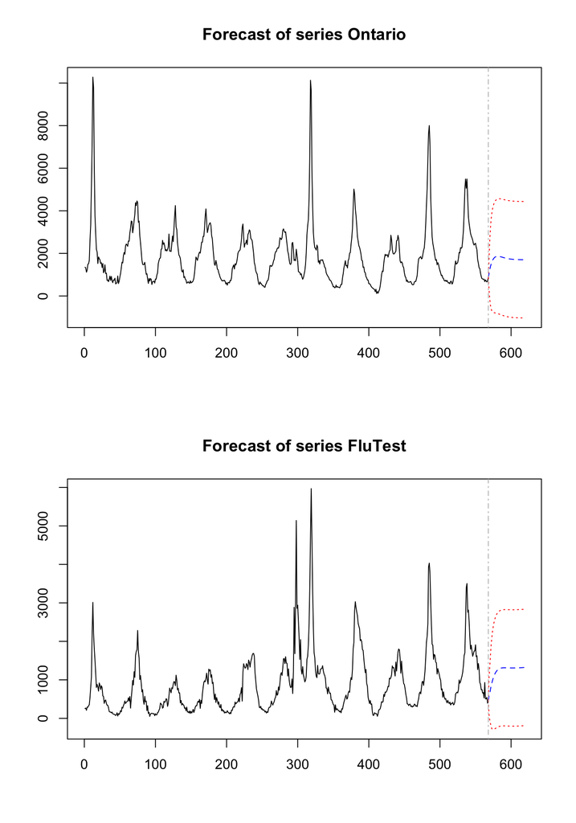

**Copyright (c) 2020 JEN-WEN LIN**